# TidyTuesday: Beach volleyball

Liza Bolton

2020-05-19

- This session will be recorded and put up on [Past events](https://utoronto.sharepoint.com/sites/ArtSci-STA/ISSC/SitePages/Past-events.aspx)
- Click the stacked lines at the top left of this panel to open a helfpul navigation pane
- Remeber to fill out the [weekly check-in](https://forms.office.com/Pages/ResponsePage.aspx?id=JsKqeAMvTUuQN7RtVsVSEOKHUU3SzAJJhmOKjJhDWEpUMFhXUVE4WUNBNzNKUEhCNDBBS1QwN0tSNC4u) by Thursday at 11:30 pm ET.

# ASA DataFest Q&A

Prof Nathan Taback will drop in to answer questions you might have.

# A quick tour of the ISSC

There are three important parts of the ISSC (well 4, if you count the most important part, YOU!)

- **Slack** is where all the real-time chatting and resource sharing happens.
- [**SharePoint**](https://utoronto.sharepoint.com/sites/ArtSci-STA/ISSC/SitePages/ISSC-Home.aspx) is an archive for the community where you can find the previous [6 Sigma Sunday newsletters](https://utoronto.sharepoint.com/sites/ArtSci-STA/ISSC/SitePages/6%CF%83-Sundays.aspx), resources and recordings from [past events](https://utoronto.sharepoint.com/sites/ArtSci-STA/ISSC/SitePages/Past-events.aspx), as well as a range of resources in the [General Resources library](https://utoronto.sharepoint.com/sites/ArtSci-STA/ISSC/General%20Resources/Forms/AllItems.aspx).
- [**ASA DataFest@UofT site**](https://datafestuoft.github.io/) for registration, some suggested resoruces and more information about the competition. https://datafestuoft.github.io/

# Mini-challenge

Your mission, should you choose to accept it, is to complete a mini-data visualisation challenge by the end of the day.

## 1. Set up GitHub

You can definitely do this challenge even if you haven’t sorted out your GitHub yet, but I’d strongly recommend making this one of your ISSC goals. More information in [the first 6 Sigma Sunday newsletter](https://utoronto.sharepoint.com/sites/ArtSci-STA/ISSC/SitePages/6.aspx). You may wish to create a repository to store this mini-project in called ‘ISSC’ or ‘TidyTuesday’ folder. I have one called [‘ISSC’](https://github.com/elb0/ISSC) with the files from the this AND the two previous TidyTuesday & Talks.

## 2. Create an R Markdown document

Or it could be an R Script, but I prefer RMDs, like what this is written in. It is perfect for when you want your code, outputs and commentary to all be together.

## 3. Install/load packages

If you haven’t installed `tidyverse` yet, you will need that package for today. It has `dplyr` and `ggplot` in it.

## 4. Load the data for this week.

There is more than one way to get this data. I’m going to use the `tidytuesdayR` package becasue I installed it last week. Choose the way that is right for you from [these options.](https://github.com/rfordatascience/tidytuesday/blob/master/data/2020/2020-05-19/readme.md#get-the-data-here)

```r
tuesdata <- tidytuesdayR::tt_load('2020-05-19')
vb_matches <- tuesdata$vb_matches
rm(tuesdata) # remove the original file because we don't need it any more
```

## 5. Take a look at the data

```r
glimpse(vb_matches)
```

```
Rows: 76,756
Columns: 65
$ circuit               <chr> "AVP", "AVP", "AVP", "AVP", "AVP", "AVP", "AVP", "AVP", "AVP", "AVP", "AVP", "AVP", "A…
$ tournament            <chr> "Huntington Beach", "Huntington Beach", "Huntington Beach", "Huntington Beach", "Hunti…
$ country               <chr> "United States", "United States", "United States", "United States", "United States", "…
$ year                  <dbl> 2002, 2002, 2002, 2002, 2002, 2002, 2002, 2002, 2002, 2002, 2002, 2002, 2002, 2002, 20…
$ date                  <date> 2002-05-24, 2002-05-24, 2002-05-24, 2002-05-24, 2002-05-24, 2002-05-24, 2002-05-24, 2…
$ gender                <chr> "M", "M", "M", "M", "M", "M", "M", "M", "M", "M", "M", "M", "M", "M", "M", "M", "M", "…
$ match_num             <dbl> 1, 2, 3, 4, 5, 6, 7, 8, 9, 10, 11, 12, 13, 14, 15, 16, 17, 18, 19, 20, 21, 22, 23, 24,…
$ w_player1             <chr> "Kevin Wong", "Brad Torsone", "Eduardo Bacil", "Brent Doble", "Albert Hannemann", "Jas…
$ w_p1_birthdate        <date> 1972-09-12, 1975-01-14, 1971-03-11, 1970-01-03, 1970-05-04, 1974-07-21, 1970-11-30, 1…
$ w_p1_age              <dbl> 29.69473, 27.35661, 31.20329, 32.38604, 32.05476, 27.84120, 31.47981, 29.92197, 29.716…
$ w_p1_hgt              <dbl> 79, 78, 74, 78, 75, 75, 78, 77, 75, 79, 73, 79, 78, 77, 73, 77, 79, 78, 75, 77, 75, 73…
$ w_p1_country          <chr> "United States", "United States", "Brazil", "United States", "United States", "United …
$ w_player2             <chr> "Stein Metzger", "Casey Jennings", "Fred Souza", "Karch Kiraly", "Jeff Nygaard", "Paul…
```

[output cut: 52 more lines]

## 6. Wrangle the data

This data is pretty clean and tidy but we might want to play with a few things.

```r
player_info <- player_matches %>%
  select(player, birthdate, height, country) %>%
  unique()
```

```
Error: Can't subset columns that don't exist.
x The column `height` doesn't exist.
```

## 7. Create at least 3 exploratory plots/summary statistics.

You might find the [Cookbook for R graphics from the BBC](https://bbc.github.io/rcookbook/) helpful, as well as the resources in [6 Sigma Sunday #2](https://utoronto.sharepoint.com/sites/ArtSci-STA/ISSC/SitePages/6%CF%83-Sunday--2.aspx) on using dplyr and ggplot.

### Explore!

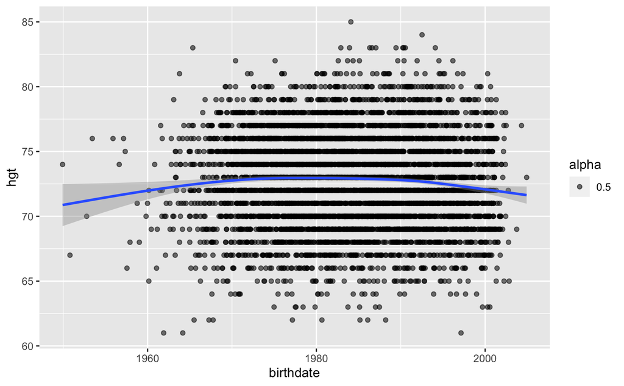

### Explore!

### Explore!

## 8. Choose one plot to improve and use/include the following:

### A title and subtitle

### Labelled axes

### A caption acknowledging the data source + your name

### An appropriate colour palette

### Explicitly use a theme (check out this list of defaults included with ggplot or get the ggtheme package)

### BONUS: Add an annotation

## 9. Save the plot using ggsave().

If you run `?ggsave`, it will tell you that “`ggsave()` is a convenient function for saving a plot. It defaults to saving the last plot that you displayed, using the size of the current graphics device. It also guesses the type of graphics device from the extension.”

## 10. Share the plot and link to your commented code with all your working in #portfolio-building with a 1–2 sentence explanation by the end of Tuesday May 19 (bonus if you share it on Twitter with #TidyTuesday). Our ISSC Tweeps are on [this list](https://twitter.com/i/lists/1258455620111515648/members). Message me if you want to be added!

Thanks everyone!

🛎 Please make sure you fill out the [weekly check-in](https://forms.office.com/Pages/ResponsePage.aspx?id=JsKqeAMvTUuQN7RtVsVSEOKHUU3SzAJJhmOKjJhDWEpUMFhXUVE4WUNBNzNKUEhCNDBBS1QwN0tSNC4u) by Thursday at 11:30 pm ET.